# Final Project

Pei-Chen Wu

2023-11-04

## Introduction

Our lab is currently working on using RibOxi-seq to pinpoint 2’O methylation (Nm) sites on mRNA molecules. This method relies on the protective nature of methylation, which shields these RNA sites from oxidation elimination reactions, allowing us to integrate them into a library for subsequent sequencing. However, before we can apply this assay to mRNA, it’s crucial to ensure its effectiveness. Therefore, in this project, I will use rRNA RibOxi-seq data, in which we mapped the Nm sites on rRNA since we already know where these Nm sites are located on rRNA. This will help us assess the feasibility of this assay on mRNA mapping

```r
library(tidyverse)
library(readxl)
library(ggpubr)
```

## Import data

```r
rRNA_PW <- read_excel("rRNA_PW .xlsx")
glimpse(rRNA_PW)
```

```
## Rows: 6,923
## Columns: 11
## $ Gene  <chr> "RNA18SN5", "RNA18SN5", "RNA18SN5", "RNA18SN5", "RNA18SN5", "RNA…
## $ Base  <dbl> 21, 22, 24, 25, 26, 27, 28, 29, 30, 31, 32, 33, 35, 37, 38, 39, …
## $ WT1   <dbl> 5, 1, 19, 1, 1, 30, 0, 0, 1, 0, 2, 1, 2, 6, 3, 6, 7, 8, 13, 9, 2…
## $ WT2   <dbl> 3, 1, 11, 0, 0, 47, 3, 1, 2, 0, 0, 0, 2, 1, 7, 0, 2, 8, 21, 8, 1…
## $ WT5   <dbl> 4, 1, 12, 0, 0, 112, 4, 0, 0, 0, 2, 0, 3, 7, 1, 0, 6, 12, 25, 11…
## $ DKO2  <dbl> 6, 0, 19, 0, 0, 20, 1, 0, 0, 0, 0, 0, 1, 2, 1, 0, 1, 2, 5, 0, 3,…
## $ DKO3  <dbl> 0, 0, 19, 3, 1, 69, 1, 0, 2, 3, 1, 1, 6, 12, 3, 4, 4, 12, 31, 14…
## $ DKO12 <dbl> 6, 0, 14, 0, 0, 10, 0, 0, 0, 1, 0, 1, 0, 0, 1, 0, 0, 3, 1, 0, 1,…
## $ Mean  <dbl> 4.0000000, 1.0000000, 14.0000000, 0.3333333, 0.3333333, 63.00000…
## $ score <dbl> 0.53333333, 0.11111111, 21.00000000, 0.04651163, 0.01052632, 47.…
## $ known <chr> NA, NA, NA, NA, NA, "yes", NA, NA, NA, NA, NA, NA, NA, NA, NA, N…
```

## Tidy data

In this experiment, we used 3 WT (Wild Type) samples and 3 KO (Knockout) samples. To tidy up the data, I calculated the mean count values for WT and KO, and created two new variables, “Genotype” and “Count_mean.”

```r
rRNA_PW <- rRNA_PW %>% rowwise() %>% mutate(WT=mean(c(WT1,WT2,WT5)))
rRNA_PW <- rRNA_PW %>% rowwise() %>% mutate(DKO=mean(c(DKO2,DKO3,DKO12)))
rRNA_tidy <- rRNA_PW %>%
  pivot_longer(WT:DKO, names_to = "Genotype", values_to = "Count_mean")
glimpse(rRNA_tidy)
```

```
## Rows: 13,846
## Columns: 13
## $ Gene       <chr> "RNA18SN5", "RNA18SN5", "RNA18SN5", "RNA18SN5", "RNA18SN5",…
## $ Base       <dbl> 21, 21, 22, 22, 24, 24, 25, 25, 26, 26, 27, 27, 28, 28, 29,…
## $ WT1        <dbl> 5, 5, 1, 1, 19, 19, 1, 1, 1, 1, 30, 30, 0, 0, 0, 0, 1, 1, 0…
## $ WT2        <dbl> 3, 3, 1, 1, 11, 11, 0, 0, 0, 0, 47, 47, 3, 3, 1, 1, 2, 2, 0…
## $ WT5        <dbl> 4, 4, 1, 1, 12, 12, 0, 0, 0, 0, 112, 112, 4, 4, 0, 0, 0, 0,…
## $ DKO2       <dbl> 6, 6, 0, 0, 19, 19, 0, 0, 0, 0, 20, 20, 1, 1, 0, 0, 0, 0, 0…
## $ DKO3       <dbl> 0, 0, 0, 0, 19, 19, 3, 3, 1, 1, 69, 69, 1, 1, 0, 0, 2, 2, 3…
## $ DKO12      <dbl> 6, 6, 0, 0, 14, 14, 0, 0, 0, 0, 10, 10, 0, 0, 0, 0, 0, 0, 1…
## $ Mean       <dbl> 4.0000000, 4.0000000, 1.0000000, 1.0000000, 14.0000000, 14.…
## $ score      <dbl> 0.53333333, 0.53333333, 0.11111111, 0.11111111, 21.00000000…
## $ known      <chr> NA, NA, NA, NA, NA, NA, NA, NA, NA, NA, "yes", "yes", NA, N…
## $ Genotype   <chr> "WT", "DKO", "WT", "DKO", "WT", "DKO", "WT", "DKO", "WT", "…
## $ Count_mean <dbl> 4.0000000, 4.0000000, 1.0000000, 0.0000000, 14.0000000, 17.…
```

## Examining all know Nm sites

First, I’d like to see if the known sites exhibit higher counts. As I mentioned earlier, we already know the Nm sites on rRNA. Therefore, we should expect to observe higher counts at these known Nm sites and lower counts at locations that are not Nm sites. As expected, the Nm sites show higher counts in both the 18S and 28S rRNA.

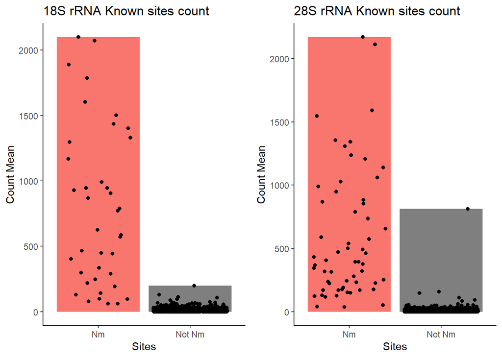

```r
kn_18s<-rRNA_tidy %>%
  dplyr::filter(Gene%in%"RNA18SN5") %>%
  dplyr::filter(Genotype=="WT") %>%
  dplyr::arrange(Count_mean) %>%
  dplyr::mutate( known= factor(known, levels=c("yes", "NA"))) %>%
  ggplot(aes(x=known, y=Count_mean,fill=known)) +
  geom_bar(position="dodge", stat="identity",show.legend = FALSE)+
  geom_jitter(show.legend = FALSE)+
  scale_x_discrete(labels=c("Nm", "Not Nm")) +
  xlab("Sites") +
  ylab("Count Mean")+
  ggtitle("18S rRNA Known sites count ")+
  theme(legend.position = "none")+
  theme_classic()

kn_28s<-rRNA_tidy %>%
  dplyr::filter(Gene%in%"RNA28SN5") %>%
  dplyr::filter(Genotype=="WT") %>%
  dplyr::arrange(Count_mean) %>%
  dplyr::mutate( known= factor(known, levels=c("yes", "NA"))) %>%
  ggplot(aes(x=known, y=Count_mean,fill=known )) +
  geom_bar(position="dodge", stat="identity", show.legend = FALSE)+
  geom_jitter(show.legend = FALSE)+
  scale_x_discrete(labels=c("Nm", "Not Nm")) +
  xlab("Sites") +
  ylab("Count Mean")+
  ggtitle("28S rRNA Known sites count ")+
  theme(legend.position = "none")+
  theme_classic()

ggarrange(kn_18s,kn_28s)
```

```r
#annotate_figure(Figure_1,fig.lab = "Figure 1", fig.lab.face = "bold")
```

## Examining specific known Nm site

Next, I examined a specific Nm site that is guided by our knocked out gene (Gene A). Methylation on position 1328 is guided by Gene A. Figure below shows that methylation on position 1328 is gone in the KO cells.

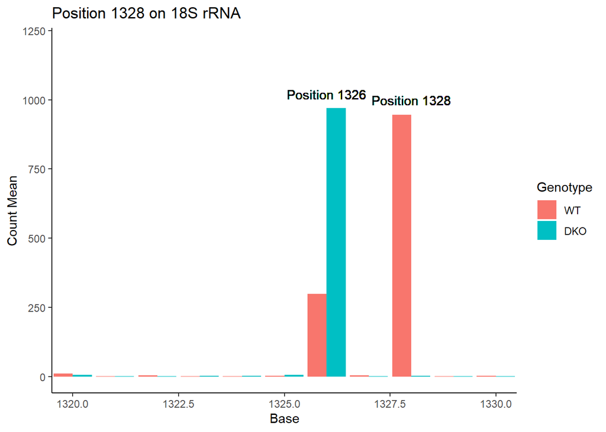

```r
rRNA_tidy %>%
  dplyr::filter(Gene %in% "RNA18SN5") %>%
  dplyr::filter(!is.na(Count_mean)) %>%
  dplyr::arrange(Count_mean) %>%
  dplyr::mutate( Genotype= factor(Genotype, levels=c("WT", "DKO"))) %>%
  ggplot(aes(fill=Genotype, y=Count_mean, x=Base)) +
  geom_bar(position="dodge", stat="identity")+
  labs(y="Count Mean",title = "Position 1328 on 18S rRNA" )+
  geom_text(x=1326, y=1020, label="Position 1326")+
  geom_text(x=1328, y=1000, label="Position 1328")+
  theme_classic()+
  coord_cartesian(xlim = c(1320,1330),ylim = c(0,1200))
```

## U6 snRNA counts

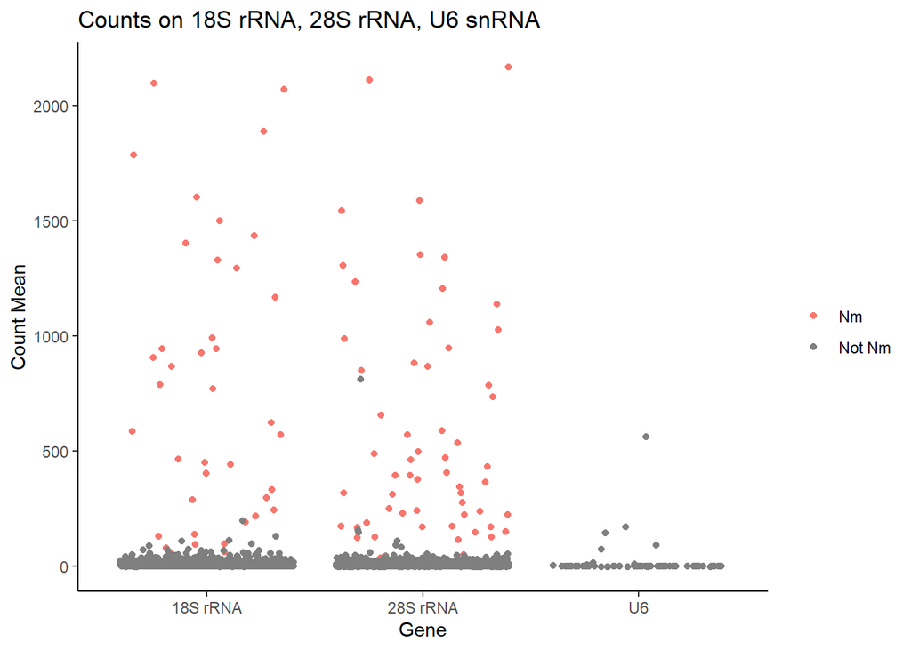

```r
rRNA_tidy %>%
  dplyr::filter(Genotype=="WT") %>%
  dplyr::filter(Gene %in% c("RNA18SN5","RNA28SN5","U6")) %>%
  ggplot(aes(x = Gene, y = Count_mean )) +
  geom_jitter(aes(colour = known) )+
  scale_color_discrete(name="", labels = c("Nm", "Not Nm"))+
  labs(y="Count Mean",title = "Counts on 18S rRNA, 28S rRNA, U6 snRNA")+
  scale_x_discrete(labels=c("18S rRNA", "28S rRNA", "U6")) +
  theme_classic()
```

## Acknowledgements

I would like to thank Dr. Yinzhou Zhu gor the RibOxi-seq data. I would also like to thank Dr. Matt Hirschey and the Tidybio TAs for their instruction over the past two weeks. Lastly, I would like to thank my colleagues and PI in the Holley Lab.